# Did i lose interest after she said yes?

The data used in this analysis are downloaded from facebook. Information can be found [Here.](https://www.facebook.com/help/1701730696756992?helpref=hc_global_nav) We are concerned if there is a decline in message volume, after my partner said yes.

*Disclaimer:* This is just for fun. Since we're both adults, we prefer hanging out together, plus we both have responsibilities. Inspiration came from the book [Probabillistic Programming.](https://github.com/CamDavidsonPilon/Probabilistic-Programming-and-Bayesian-Methods-for-Hackers)

For security reasons, i will not show any actual message. Data was cleaned by looping through the JSON object, then extract a list of:

- Message sender
- Time Sent
- Message Content

Message sender was then mapped to Message sent for messages from myself, and message received for messages from my girlfriend.

Final dataframe will be shown below.

Below is the first five rows of our dataset, precise up to the nearest minute.

|  | time | message_content | message_status |
| --- | --- | --- | --- |
| 29236 | 2019-08-28 13:13:00 | 2 | Messages Sent |
| 29235 | 2019-08-28 13:07:00 | 2 | Messages Received |
| 29234 | 2019-08-28 13:07:00 | 4 | Messages Sent |
| 29233 | 2019-08-28 13:05:00 | 1 | Messages Received |
| 29232 | 2019-08-28 13:05:00 | 2 | Messages Sent |

Below is the first five rows of our dataset, precise up to the nearest day.

|  | daily | message_content | message_status |
| --- | --- | --- | --- |
| 363 | 08/28/2019 | 95 | Messages Received |
| 362 | 08/28/2019 | 121 | Messages Sent |
| 361 | 08/27/2019 | 1 | Messages Received |
| 360 | 08/27/2019 | 5 | Messages Sent |
| 359 | 08/26/2019 | 511 | Messages Received |

# Exploratory Data Analysis

There seems to be a decreasing trend. There are significantly more messages sent during March. This maskes sense as this is the 'getting to know period.' One thing to note though, is that i maintained sending her more messages, than she sends me in the entire date range.

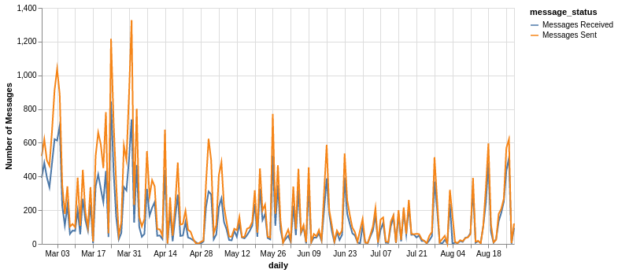

Most of the messages are sent on Sunday and Monday. This makes sense as well because from March to end of May, i'm still at my previous company and our weekends are Sundays and Mondays.

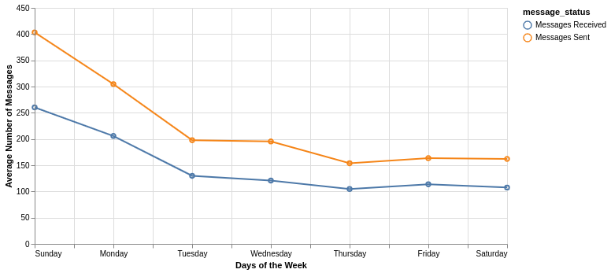

Since the trend for message received and message sent is similar, (meaning i'm actually getting replies from her) it suffices to check the messages that i've sent her.

- During March, it's almost like i'm sending her messages the entire day.
- As the months goes by, most messages are sent at the beginning and end of each day.

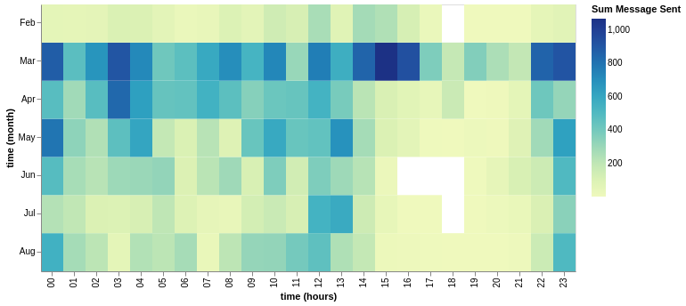

# Inference

Now, let's transform our data suitable for inference. We will do the following:

- Drop the message count for message received. After all, we're only concerned if there's a significant decrease in messages sent after we became a couple.
- We will only consider messages sent from April Onwards, as it's already given that Messages sent on March are significantly higher.
- Aggregate by date, then map the date to integers from $0 - n$.

Now, we are interested if there is a significant increase/decrease in messages sent, after my partner said yes. We will assume that the messages that i've sent follows a *Poisson Distribution.* As we know, this has a parameter $\lambda.$ To solve our problem, We will define it as

$$ \lambda = \begin{cases} \lambda_1 & \text{if } t \lt 56 \cr \lambda_2 & \text{if } t \ge 56 \end{cases} $$

if $\lambda_1=\lambda_2$ then it implies that there are no significant change in message volume. How will we get $\lambda_is?$ Remember that $\lambda$ is a parameter from *Poisson* and hence, it should be a positive real number. We will model this by assuming that it came from a *Exponential Distribution* with a parameter $\alpha.$

$\alpha$ is a hyper-parameter. We will set the exponential parameter equal to the inverse of the average of the `df['Message Count']`.

**TLDR:** We will use PyMC3 to get the probability distribution for 2 lambdas. We will compare their expected values, and if they are equal, then there are no significant increase/decrease in message volume.

Filtering the date when my partner said yes.

|  | Days | Date | Message Count |
| --- | --- | --- | --- |
| 56 | 56 | 05/27/2019 | 179 |

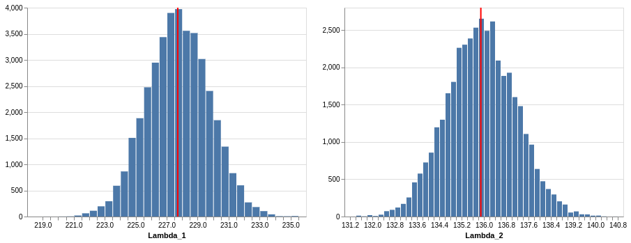

As seen from the plot above, $E(\lambda_1) > E(\lambda_2).$ Then it is clear that indeed, there is a drop in message volume since remember, If $\lambda>>N$ , then the distribution assigns larger probabilities to larger values.